# Time course analysis

**Purpose:** We want to characterize the change in the microbiome over the course of the model

### Setup

```r
library(randomForest, quietly=TRUE)
library(knitr, quietly=TRUE)

set.seed(6201976)

source("code/rf_baseline_analysis.R")
```

First, we want to read in the distance matrix and see which treatments are changing the most…

```
##      Group.1   x.Min. x.1st Qu. x.Median   x.Mean x.3rd Qu.   x.Max.
## 1     AllAbs 0.001237  0.007671 0.030260 0.208200  0.458500 0.614700
## 2      Metro 0.489800  0.588500 0.641800 0.619900  0.646700 0.732600
## 3      NoAbs 0.326700  0.571600 0.669600 0.654000  0.780500 0.914500
## 4      Strep 0.110600  0.166600 0.174000 0.331900  0.538700 0.669700
## 5 StrepMetro 0.679100  0.742100 0.795900 0.779900  0.827400 0.855100
## 6       Vanc 0.070500  0.082360 0.094210 0.116000  0.138700 0.183200
## 7  VancMetro 0.068550  0.103500 0.138500 0.130400  0.161400 0.184300
## 8  VancStrep 0.857500  0.872500 0.888200 0.903900  0.936600 0.964600
```

Was surprised that the “AllAbs” seemed bimodal. Of the mice, 5 didn't move at all and 3 moved a fair amount. Curious to see how well they replicated each other at the beginning and the end of the model.

```
##           AllAbs  Metro  NoAbs   Strep StrepMetro    Vanc VancMetro
## Min.    0.001354 0.1307 0.1569 0.07413   0.008213 0.03332   0.03032
## 1st Qu. 0.008829 0.1959 0.2598 0.09710   0.058240 0.03365   0.03979
## Median  0.015120 0.2389 0.4541 0.12920   0.152600 0.03398   0.04926
## Mean    0.055430 0.2332 0.4285 0.15360   0.187100 0.04207   0.06302
## 3rd Qu. 0.111500 0.2520 0.5480 0.21040   0.300600 0.04644   0.07938
## Max.    0.161300 0.3549 0.7683 0.28080   0.472900 0.05890   0.10950
##         VancStrep
## Min.      0.07723
## 1st Qu.   0.18610
## Median    0.38480
## Mean      0.44140
## 3rd Qu.   0.71920
## Max.      0.81380
```

Again, I was struck by the variation among the Day 0 samples for all antibiotics. Let's see what it looks like at the end of the model…

```
##           AllAbs  Metro  NoAbs   Strep StrepMetro   Vanc VancMetro
## Min.    0.001725 0.1143 0.2334 0.03205    0.01524 0.1006   0.01764
## 1st Qu. 0.031450 0.1822 0.5819 0.16300    0.04075 0.1067   0.07927
## Median  0.448100 0.2883 0.6930 0.30720    0.06168 0.1128   0.17660
## Mean    0.324300 0.2899 0.6695 0.30440    0.12850 0.1580   0.20160
## 3rd Qu. 0.596200 0.3315 0.7928 0.42700    0.24280 0.1867   0.33230
## Max.    0.665000 0.6047 0.9250 0.58280    0.28290 0.2605   0.40790
##         VancStrep
## Min.      0.02841
## 1st Qu.   0.04940
## Median    0.06062
## Mean      0.07115
## 3rd Qu.   0.07190
## Max.      0.16450
```

More variation at the end point.

What happens when we plot the distance changed between day 0 and the end with the number of tumors that were observed?

```
## Error in `[.data.frame`(tumor_counts, names(start_end_dist)): undefined columns selected
```

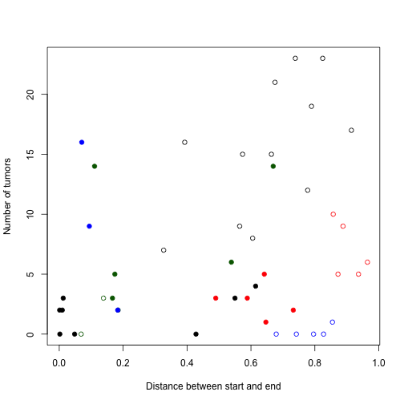

My eye wants to see some type of saturation curve where the more distance between the start and end point, the more tumors occur. But… the \(\rho\) statistic was 0.26 (P= 0.08).

Let's break down and build an ordination…

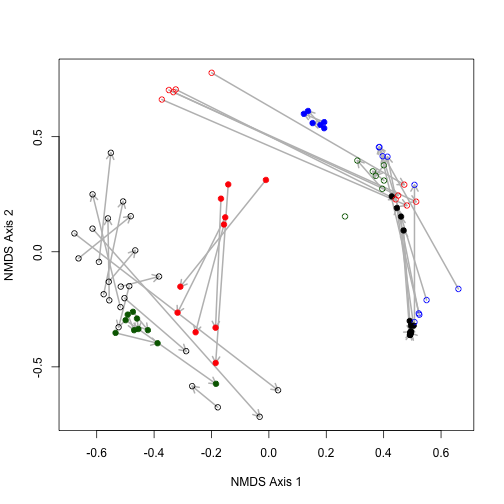

Let's see whether we can build a random forest to predict whether a sample comes from the beginning or the end of the model.

Looks pretty crappy. Here's the confusion matrix:

|  | begin | end | class.error |
| --- | --- | --- | --- |
| begin | 35 | 11 | 0.2391304 |
| end | 8 | 40 | 0.1666667 |

The out of bag error rate was 20.2%.

How about if we do it based on the final samples and see whether there was overlap with the OTUs we detected at the beginning of the model.

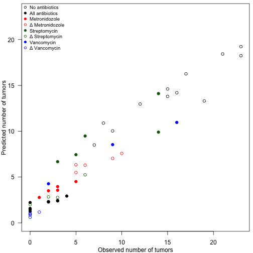

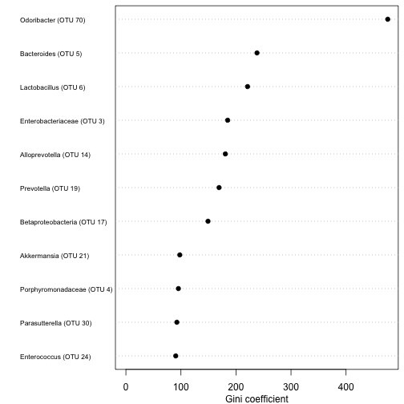

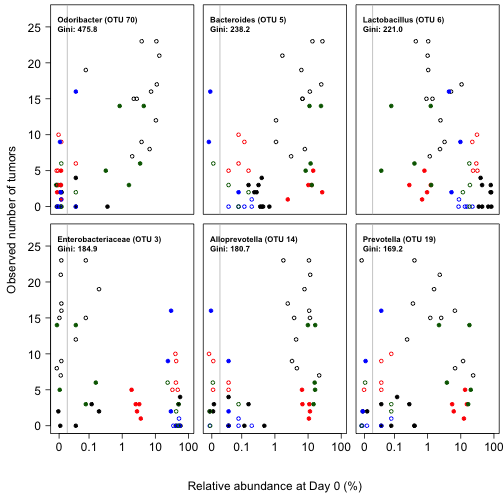

This model does a pretty good job of predicting the number of tumors, but it is pretty redundant with the mBio paper and the baseline model.

Let's try building a model to connect change in relative abundance between baseline and the end point with the number of tumors

This results in 4 OTUs - Ecoli, Bacteroidetes, Odoribacter, and Beta-proteobacteria. Not sure what it really says…